# Reproducible Research - Course Project 1

### Loading and preprocessing the data

To load and preprocess the data for my analysis, I run the following code.

```r
# First, I load the data within the 'activity.csv' file in the workspace
# using the read.csv function
DF <- read.csv("activity.csv")
# Then I do my preprocessing. Here I only convert the date to Date classes
# in R.
DF$date <- as.Date(DF$date, origin = "2012-10-01")
```

### What is mean total number of steps taken per day?

It is said that for this part of assignement, we can *ignore the missing values* in the dataset. So *no special processing* will be made (for now) to remove them from the dataset.

To begin with my analysis, I plot a **histogram of the total number of steps taken each day**.

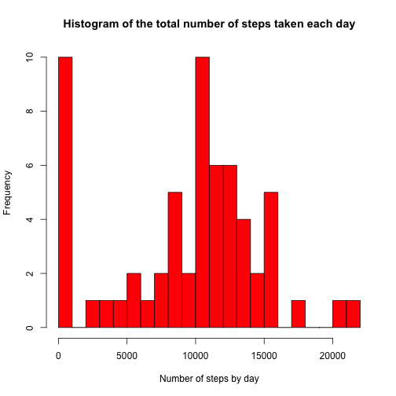

```r
# First, I use the 'tapply' function to estimate the total number of steps
# taken each day.
stepsByDay <- tapply(DF$steps, DF$date, sum, na.rm = TRUE)
# To plot the histogram, I choose to use the hist function from the base
# plotting system
hist(stepsByDay, breaks = 20, col = "red", xlab = "Number of steps by day",
    main = "Histogram of the total number of steps taken each day")
```

At first sight, we can see that there is a significant number of days whom number of steps taken is very low. It may be due to the presence of missing values in the dataset. But we can't conclude for the moment.

Then I estimate the **mean** and **median** total number of steps taken per day using the following R code.

```r
mean <- mean(stepsByDay, na.rm = TRUE)
median <- median(stepsByDay, na.rm = TRUE)
```

So, at the end of this part, both **mean** and **median** have been estimated. The **mean** is **9354 steps** a day and the **median** is **10395 steps** a day.

### What is the average daily activity pattern?

First, I make a *time series plot of the 5-minute interval (x-axis) and the average number of steps taken, averaged across all days (y-axis)*. In that aim, the averaged number of steps taken by 5-min interval have to be calculated. Here again, we use the **tapply** function.

```r
stepsByInterval <- tapply(DF$steps, DF$interval, mean, na.rm = TRUE)
```

Now the plot can be made.

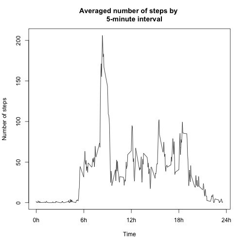

```r
numberOfInterval <- 24 * 60/5
plot(x = DF$interval[1:numberOfInterval], y = stepsByInterval, type = "l", xlab = "Time",
    ylab = "Number of steps", main = "Averaged number of steps by \n     5-minute interval",
    xaxt = "n")
axis(1, seq(1, 2400, length.out = 5), labels = c("0h", "6h", "12h", "18h", "24h"))
```

Visually, the 5-minute interval containing **the maximum number of steps seems to be around 8:00** but a more precise value can be found within **stepsByInterval** with some calculation.

```r
max <- max(stepsByInterval)
startInterval <- names(stepsByInterval)[which.max(stepsByInterval)]
endInterval <- names(stepsByInterval)[which.max(stepsByInterval) + 1]
# The following code is used to diplay 'correctly' the hour.
startInterval <- paste(rep(x = "0", time = 4 - nchar(startInterval)), startInterval,
    sep = "")
begin <- format(strptime(startInterval, "%H%M"), "%H:%M")
endInterval <- paste(rep(x = "0", time = 4 - nchar(endInterval)), endInterval,
    sep = "")
end <- format(strptime(endInterval, "%H%M"), "%H:%M")
```

The maximum number of steps is made between **08:35** and **08:40**. And the maximum is **206 steps during this 5-minute interval**.